# Project - Ensemble Techniques - Travel Package Purchase Prediction

#### PitchSatisfactionScore Vs ProdTaken

```
ProdTaken                  0    1   All
PitchSatisfactionScore
All                     3853  894  4747
3                       1123  304  1427
5                        725  198   923
4                        709  160   869
1                        798  144   942
2                        498   88   586
----------------------------------------------------------------------------------------------------
```

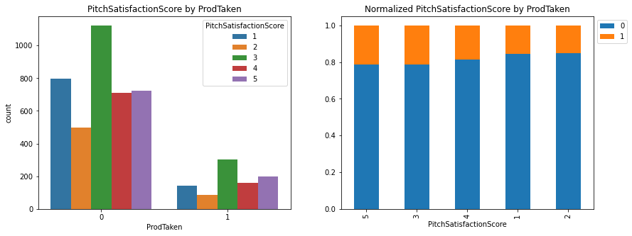

```python
count_and_normalize_plot(data, 'PitchSatisfactionScore', 'ProdTaken')
```

> **Observations:**
> - Most of the customers who have taken a travel package gave average 3 pitch satisfaction score.
> - Interesting to see that when pitch satisfaction score is 5 higher percentage of customers from this category have taken a travel package.

#### OwnCar Vs ProdTaken

```
ProdTaken     0    1   All
OwnCar
All        3853  894  4747
1          2390  542  2932
0          1463  352  1815
----------------------------------------------------------------------------------------------------
```

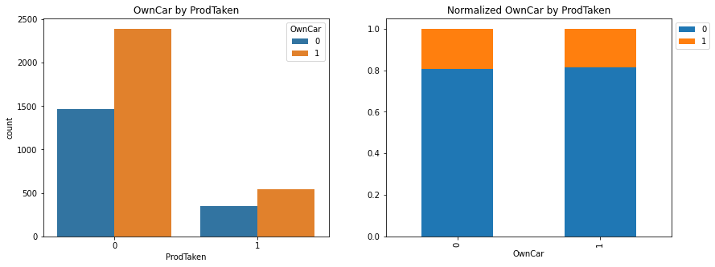

```python
count_and_normalize_plot(data, 'OwnCar', 'ProdTaken')
```

> **Observations:**
> - Owning a car did not make much difference with regards to product taken.

#### NumberOfChildrenVisiting Vs ProdTaken

```
ProdTaken                    0    1   All
NumberOfChildrenVisiting
All                       3853  894  4747
1.0                       1688  386  2074
2.0                       1056  248  1304
0.0                        851  194  1045
3.0                        258   66   324
----------------------------------------------------------------------------------------------------
```

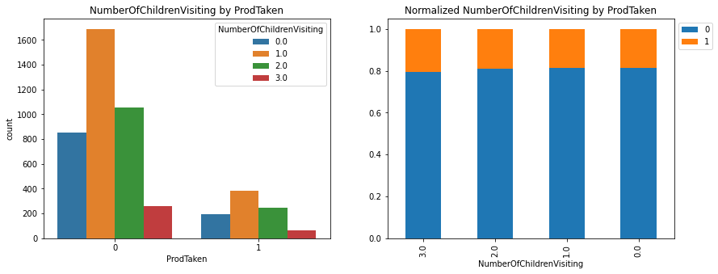

```python
count_and_normalize_plot(data, 'NumberOfChildrenVisiting', 'ProdTaken')
```

#### Designation Vs ProdTaken

```
ProdTaken          0    1   All
Designation
All             3853  894  4747
Executive       1260  540  1800
Manager         1486  198  1684
Senior Manager   594  120   714
VP               205   20   225
AVP              308   16   324
----------------------------------------------------------------------------------------------------
```

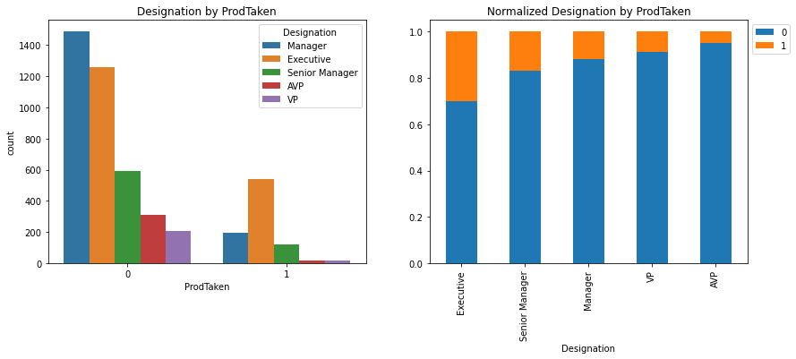

```python
count_and_normalize_plot(data, 'Designation', 'ProdTaken')
```

> **Observations:**
> - Most of the customers who have taken a travel package are Executives, in other words, designation with lowest median monthly salary.
> - Higher designation with higher median monthly income have not preferred the travel packages.

Based on the data dictionary and observations we see ProductPitched and Designation values are ordered or ranked in nature. Hence we will encode these features with ordered numerical values. Chances are that Designation and Monthly Income may be highly correlated.

```python
#data_bkp2 = data.copy()
replaceStruct = {
        "ProductPitched": {"Basic": 1, "Standard":2 , "Deluxe": 3, "Super Deluxe": 4,"King": 5},
        "Designation":     {"Executive": 1, "Manager": 2 ,"Senior Manager": 3 ,"AVP": 4, "VP": 5}
    }
data=data.replace(replaceStruct)
```

```python
data.head()
```

|  | ProdTaken | Age | TypeofContact | CityTier | DurationOfPitch | Occupation | Gender | NumberOfPersonVisiting | NumberOfFollowups | ProductPitched | PreferredPropertyStar | MaritalStatus | NumberOfTrips | Passport | PitchSatisfactionScore | OwnCar | NumberOfChildrenVisiting | Designation | MonthlyIncome |
| --- | --- | --- | --- | --- | --- | --- | --- | --- | --- | --- | --- | --- | --- | --- | --- | --- | --- | --- | --- |
| 0 | 1 | 41.0 | Self Enquiry | 3 | 6.0 | Salaried | Female | 3 | 3.0 | 3 | 3.0 | Single | 1.0 | 1 | 2 | 1 | 0.0 | 2 | 20993.0 |
| 1 | 0 | 49.0 | Company Invited | 1 | 14.0 | Salaried | Male | 3 | 4.0 | 3 | 4.0 | Divorced | 2.0 | 0 | 3 | 1 | 2.0 | 2 | 20130.0 |
| 2 | 1 | 37.0 | Self Enquiry | 1 | 8.0 | Free Lancer | Male | 3 | 4.0 | 1 | 3.0 | Single | 7.0 | 1 | 3 | 0 | 0.0 | 1 | 17090.0 |
| 3 | 0 | 33.0 | Company Invited | 1 | 9.0 | Salaried | Female | 2 | 3.0 | 1 | 3.0 | Divorced | 2.0 | 1 | 5 | 1 | 1.0 | 1 | 17909.0 |
| 4 | 0 | 36.0 | Self Enquiry | 1 | 8.0 | Small Business | Male | 2 | 3.0 | 1 | 4.0 | Divorced | 1.0 | 0 | 5 | 1 | 0.0 | 1 | 18468.0 |

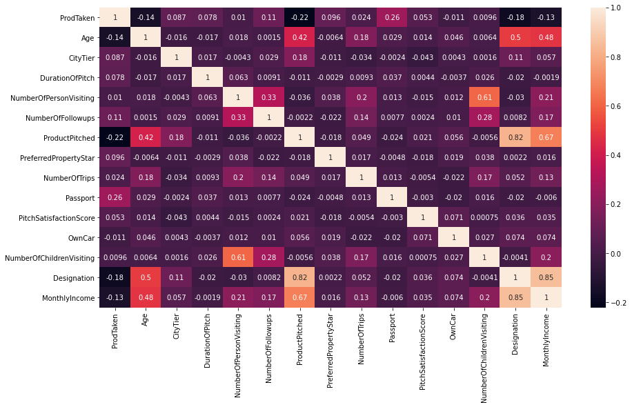

```python
# Check the correlation between features
plt.figure(figsize=(15,8))
sns.heatmap(data.corr(), annot=True);
```

> **Observations:**
> - As expected Designation and Mothly income are highly correlated (0.85)
> - Designation and Product Pitched are also highly correlated (0.82), which again makes sense as company may have pitched higher value products to higer designated customers.
> - Similarly we can also see correlation (0.67) between Product Pitched and Monthly income. Although not very strong.
> - Number of children visiting and number of persons visiting are also correlated (0.61)
> - Age has positive correlation with Monthly Income and Designation which is also self explanatory.
> - There is no significant correlation among other features.

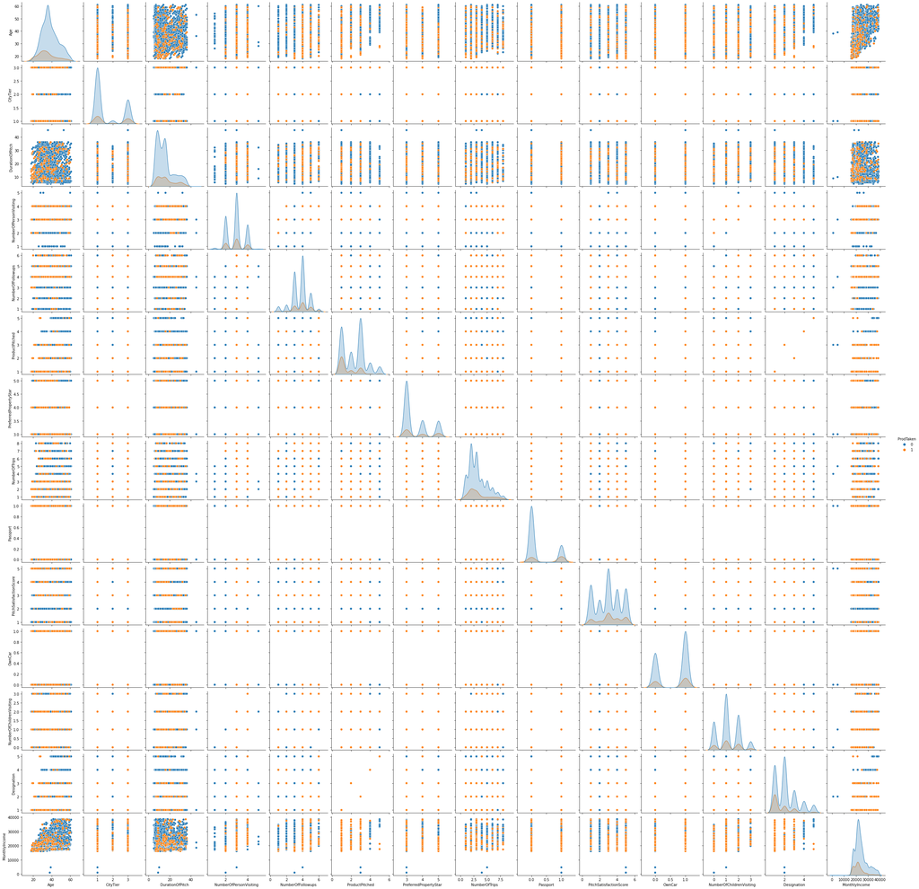

```python
# Let us see the pairplot for all numerical variables
sns.pairplot(data, hue='ProdTaken');
```

## Model Building

We are going to now build several classification models based on Ensemble Techniques. However for each model the evaluation criteria remains same. At the end we'll compare the performance of all the models and provide recommendations for **"Visit With Us"** marketing department Wellness Travel Package campaign. We are going to follow below steps:

1. Split the data into the train and test set.
2. Train models on the training data.
3. Try to improve the model performance using hyperparameter tuning.
4. Test the performance on the test data.

### Model evaluation criterion:

### Model can make wrong predictions as:

1. Predicting a person who has taken a travel package but in reality he/she did not.
2. Predicting a person who did not take a travel package but in reality he/she did.

### Which case is more important?

- Predicting a person who has taken a travel package but in reality he/she did not then cost related to marketing on travel package to the customer is wasted. While we are looking to optimize the marketting cost but this has less importance than an oppertunity cost.
- If we predict a customer who did not take a travel package but in reality he/she did then it will be a loss of oppertunity for the company and this is precisly we want to avoid since we want to increase the customer base of travel package.

### How to reduce this loss i.e need to reduce False Negatives?

- `recall` should be maximized, the greater the `recall` higher the chances of identifying customers who would like to buy a the Wellness Tourism Package.

```python
# Libraries to split data, impute missing values
from sklearn.model_selection import train_test_split
from sklearn.impute import SimpleImputer

# Libraries to import decision tree classifier and different ensemble classifiers
from sklearn.ensemble import BaggingClassifier
from sklearn.ensemble import RandomForestClassifier
from sklearn.ensemble import AdaBoostClassifier, GradientBoostingClassifier
from xgboost import XGBClassifier
from sklearn.ensemble import StackingClassifier
from sklearn.tree import DecisionTreeClassifier

# Libtune to tune model, get different metric scores
from sklearn import metrics
from sklearn.metrics import confusion_matrix, classification_report, accuracy_score, precision_score, recall_score, f1_score, roc_auc_score
from sklearn.model_selection import GridSearchCV
```

### Split Data

```python
# Let's drop the Designation and ProductPitched feature as it is higly correlated with Monthly Income.
# Also for ProductPitched, we are not interested in a particular product, since we have new product,
# but the end result if the product was taken.
X = data.drop(['ProdTaken', 'Designation', 'ProductPitched'], axis=1)
y = data['ProdTaken']
```

```python
X = pd.get_dummies(X, drop_first=True)
# Splitting data into training and test set:
X_train, X_test, y_train, y_test =train_test_split(X, y, test_size=0.3, random_state=1,stratify=y)
print(X_train.shape, X_test.shape)
```

```
(3322, 20) (1425, 20)
```

The Stratify arguments maintain the original distribution of classes in the target variable while splitting the data into train and test sets.

```python
# Lets take look at the sample training dataset
X.sample(10)
```

|  | Age | CityTier | DurationOfPitch | NumberOfPersonVisiting | NumberOfFollowups | PreferredPropertyStar | NumberOfTrips | Passport | PitchSatisfactionScore | OwnCar | NumberOfChildrenVisiting | MonthlyIncome | TypeofContact_Self Enquiry | Occupation_Large Business | Occupation_Salaried | Occupation_Small Business | Gender_Male | MaritalStatus_Married | MaritalStatus_Single | MaritalStatus_Unmarried |
| --- | --- | --- | --- | --- | --- | --- | --- | --- | --- | --- | --- | --- | --- | --- | --- | --- | --- | --- | --- | --- |
| 4282 | 50.0 | 1 | 25.0 | 3 | 5.0 | 3.0 | 3.0 | 1 | 3 | 1 | 1.0 | 38180.0 | 1 | 0 | 1 | 0 | 1 | 1 | 0 | 0 |
| 4570 | 41.0 | 1 | 27.0 | 4 | 4.0 | 3.0 | 6.0 | 0 | 3 | 1 | 2.0 | 29000.0 | 1 | 1 | 0 | 0 | 1 | 1 | 0 | 0 |
| 4228 | 43.0 | 1 | 35.0 | 3 | 5.0 | 3.0 | 2.0 | 0 | 3 | 0 | 2.0 | 23201.0 | 0 | 1 | 0 | 0 | 0 | 1 | 0 | 0 |
| 3830 | 36.0 | 1 | 25.0 | 4 | 4.0 | 3.0 | 3.0 | 1 | 3 | 1 | 1.0 | 24367.0 | 0 | 0 | 1 | 0 | 1 | 1 | 0 | 0 |
| 2045 | 51.0 | 3 | 32.0 | 3 | 3.0 | 3.0 | 3.0 | 0 | 3 | 1 | 1.0 | 31307.0 | 1 | 0 | 0 | 1 | 0 | 1 | 0 | 0 |
| 1463 | 31.0 | 1 | 11.0 | 3 | 3.0 | 5.0 | 1.0 | 0 | 1 | 0 | 2.0 | 24936.0 | 0 | 0 | 0 | 1 | 1 | 0 | 0 | 1 |
| 3546 | 30.0 | 3 | 17.0 | 3 | 5.0 | 3.0 | 2.0 | 0 | 4 | 1 | 1.0 | 24547.0 | 1 | 0 | 0 | 1 | 1 | 0 | 0 | 1 |
| 2229 | 36.0 | 1 | 8.0 | 3 | 3.0 | 3.0 | 3.0 | 0 | 4 | 1 | 1.0 | 22311.0 | 0 | 0 | 1 | 0 | 1 | 0 | 1 | 0 |
| 2416 | 27.0 | 1 | 32.0 | 3 | 6.0 | 3.0 | 3.0 | 0 | 2 | 1 | 2.0 | 20971.0 | 1 | 0 | 1 | 0 | 1 | 0 | 1 | 0 |
| 1031 | 46.0 | 3 | 15.0 | 2 | 3.0 | 3.0 | 5.0 | 0 | 3 | 0 | 1.0 | 25096.0 | 1 | 0 | 0 | 1 | 1 | 1 | 0 | 0 |

```python
y.value_counts(1)
```

```
0    0.811671
1    0.188329
Name: ProdTaken, dtype: float64
```

```python
y_test.value_counts(1)
```

```
0    0.81193
1    0.18807
Name: ProdTaken, dtype: float64
```

In order to calculate different metrics and confusion matrix and promote code reuse we are going to write below utility functions.

- The model_performance_classification_sklearn function will be used to check the model performance of models.
- The confusion_matrix_sklearn function will be used to plot confusion matrix.
- The show_feature_imp function will show the important features for the given model when applicable

```python
# defining a function to compute different metrics to check performance of a classification model built using sklearn
def model_performance_classification_sklearn(model, predictors, target):
    """
    Function to compute different metrics to check classification model performance

    model: classifier
    predictors: independent variables
    target: dependent variable
    """

    # predicting using the independent variables
    pred = model.predict(predictors)

    acc = accuracy_score(target, pred)  # to compute Accuracy
    recall = recall_score(target, pred)  # to compute Recall
    precision = precision_score(target, pred)  # to compute Precision
    f1 = f1_score(target, pred)  # to compute F1-score

    # creating a dataframe of metrics
    df_perf = pd.DataFrame(
        {
            "Accuracy": acc,
            "Recall": recall,
            "Precision": precision,
            "F1": f1,
        },
        index=[0],
    )

    return df_perf
```

```python
def confusion_matrix_sklearn(model, predictors, target):
    """
    To plot the confusion_matrix with percentages

    model: classifier
    predictors: independent variables
    target: dependent variable
    """
    y_pred = model.predict(predictors)
    cm = confusion_matrix(target, y_pred)
    labels = np.asarray(
        [
            ["{0:0.0f}".format(item) + "\n{0:.2%}".format(item / cm.flatten().sum())]
            for item in cm.flatten()
        ]
    ).reshape(2, 2)

    plt.figure(figsize=(6, 4))
    sns.heatmap(cm, annot=labels, fmt="")
    plt.ylabel("True label")
    plt.xlabel("Predicted label")
```

```python
def show_feature_imp(model):
    """
    Show feature importance from a decision tree type models
    """
    feature_names = X_train.columns
    importances = model.feature_importances_
    indices = np.argsort(importances)

    plt.figure(figsize=(12,12))
    plt.title('Feature Importances')
    plt.barh(range(len(indices)), importances[indices], color='violet', align='center')
    plt.yticks(range(len(indices)), [feature_names[i] for i in indices])
    plt.xlabel('Relative Importance')
    plt.show()
```

## Decision Tree Classifier

```
Training performance:
    Accuracy  Recall  Precision   F1
0       1.0     1.0        1.0  1.0

Testing performance:
    Accuracy    Recall  Precision        F1
0  0.853333  0.652985   0.601375  0.626118

Confusion Matrix:
```

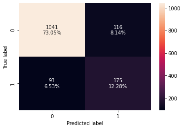

```python
#Fitting the model
d_tree = DecisionTreeClassifier(random_state=1)
d_tree.fit(X_train,y_train)

#Calculating different metrics
d_tree_model_train_perf=model_performance_classification_sklearn(d_tree,X_train,y_train)
print("Training performance:\n",d_tree_model_train_perf)
d_tree_model_test_perf=model_performance_classification_sklearn(d_tree,X_test,y_test)
print("\nTesting performance:\n",d_tree_model_test_perf)

#Creating confusion matrix
print("\nConfusion Matrix:")
confusion_matrix_sklearn(d_tree,X_test,y_test)
```

> **Observations:**
> - As expected, DecisionTreeClassifier overfits the training dataset with recall score 1.0
> - The testing recall is 0.65. Train and test recall scores have big difference.

### Hyperparameter Tuning

```python
#Choose the type of classifier.
dtree_estimator = DecisionTreeClassifier(class_weight={0:0.18,1:0.72},random_state=1)

# Grid of parameters to choose from
parameters = {'max_depth': [2, 4, 6, 8, None],
              'min_samples_leaf': [1, 2, 5, 7, 10],
              'max_leaf_nodes' : [2, 3, 5, 10,15],
              'min_impurity_decrease': [0.0001,0.001,0.01,0.1]
             }

# Type of scoring used to compare parameter combinations
scorer = metrics.make_scorer(metrics.recall_score)

# Run the grid search
grid_obj = GridSearchCV(dtree_estimator, parameters, scoring=scorer, n_jobs=-1)
grid_obj = grid_obj.fit(X_train, y_train)

# Set the clf to the best combination of parameters
dtree_estimator = grid_obj.best_estimator_

# Fit the best algorithm to the data.
dtree_estimator.fit(X_train, y_train)
```

```
DecisionTreeClassifier(class_weight={0: 0.18, 1: 0.72}, max_depth=4,
                       max_leaf_nodes=5, min_impurity_decrease=0.01,
                       random_state=1)
```

```
Training performance:
    Accuracy  Recall  Precision   F1
0       1.0     1.0        1.0  1.0
Testing performance:
    Accuracy    Recall  Precision        F1
0  0.853333  0.652985   0.601375  0.626118
```

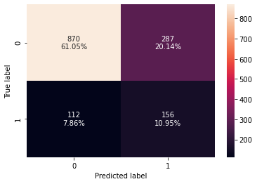

```python
#Calculating different metrics
dtree_estimator_model_train_perf=model_performance_classification_sklearn(d_tree,X_train,y_train)
print("Training performance:\n",dtree_estimator_model_train_perf)
dtree_estimator_model_test_perf=model_performance_classification_sklearn(d_tree,X_test,y_test)
print("Testing performance:\n",dtree_estimator_model_test_perf)

#Creating confusion matrix
confusion_matrix_sklearn(dtree_estimator,X_test,y_test)
```

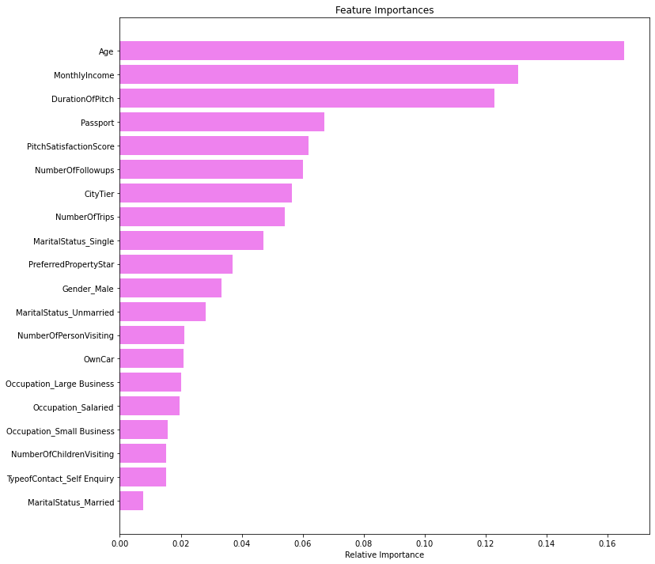

```python
show_feature_imp(d_tree)
```

## Random Forest Classifier

```
Training performance:
    Accuracy  Recall  Precision   F1
0       1.0     1.0        1.0  1.0
Testing performance:
    Accuracy    Recall  Precision        F1
0  0.897544  0.503731   0.912162  0.649038
```

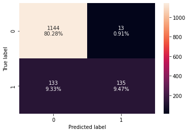

```python
#Fitting the model
rf_estimator = RandomForestClassifier(random_state=1)
rf_estimator.fit(X_train,y_train)

#Calculating different metrics
rf_estimator_model_train_perf=model_performance_classification_sklearn(rf_estimator,X_train,y_train)
print("Training performance:\n",rf_estimator_model_train_perf)
rf_estimator_model_test_perf=model_performance_classification_sklearn(rf_estimator,X_test,y_test)
print("Testing performance:\n",rf_estimator_model_test_perf)

#Creating confusion matrix
confusion_matrix_sklearn(rf_estimator,X_test,y_test)
```

> **Observations:**
> - Training and testing recall scores are 1.0 and 0.50 respectively.
> - The model is highly overfitted.

### Hyperparameter Tuning

```python
# Choose the type of classifier.
rf_tuned = RandomForestClassifier(class_weight={0:0.18,1:0.82},random_state=1,oob_score=True,bootstrap=True)

parameters = {
                'max_depth': [3, 6, 9, None],
                'max_features': ['sqrt','log2',None],
                'min_samples_leaf': np.arange(1,15,5),
                'min_samples_split': np.arange(2, 20, 5),
                'n_estimators': [20,40,80,100]
            }


# Type of scoring used to compare parameter combinations
scorer = metrics.make_scorer(metrics.recall_score)

# Run the grid search
grid_obj = GridSearchCV(rf_tuned, parameters, scoring=scorer, cv=5, n_jobs=-1)
grid_obj = grid_obj.fit(X_train, y_train)

# Set the clf to the best combination of parameters
rf_tuned = grid_obj.best_estimator_

# Fit the best algorithm to the data.
rf_tuned.fit(X_train, y_train)
```

```
RandomForestClassifier(class_weight={0: 0.18, 1: 0.82}, max_depth=3,
                       max_features='sqrt', n_estimators=80, oob_score=True,
                       random_state=1)
```

```
Training performance:
    Accuracy    Recall  Precision        F1
0  0.745334  0.699681   0.399635  0.508711
Testing performance:
    Accuracy    Recall  Precision        F1
0  0.722807  0.671642    0.36961  0.476821
```

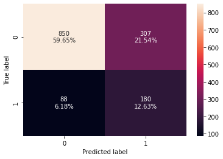

```python
#Calculating different metrics
rf_tuned_model_train_perf=model_performance_classification_sklearn(rf_tuned,X_train,y_train)
print("Training performance:\n",rf_tuned_model_train_perf)
rf_tuned_model_test_perf=model_performance_classification_sklearn(rf_tuned,X_test,y_test)
print("Testing performance:\n",rf_tuned_model_test_perf)

#Creating confusion matrix
confusion_matrix_sklearn(rf_tuned,X_test,y_test)
```

> **Observations:**
> - Training and testing recall scores are 0.69 and 0.67 respectively.
> - Although the training performance has dropped but the model is not overfitted.
> - A good improvement over the last model.

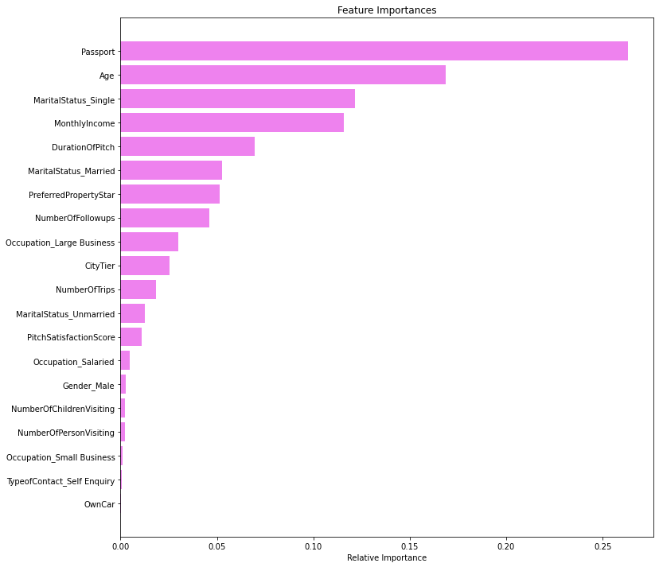

```python
show_feature_imp(rf_tuned)
```

> **Observations:**
> - The model has given high importance to Passport, Age, Single and Monthly Income.
> - It has also given importance to DurationOfPitch, Married, NumberOfFfollowups, Large Business, City Tier
> - Very low importance to Self Enquiry or OwnCar features.

## Bagging Classifier with LogisticRegression

```
Training performance:
    Accuracy   Recall  Precision        F1
0  0.813666  0.01278   0.888889  0.025197
Testing performance:
    Accuracy    Recall  Precision        F1
0   0.81614  0.026119      0.875  0.050725
```

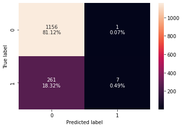

```python
#Fitting the model
from sklearn.linear_model import LogisticRegression
lg_bagging_classifier = BaggingClassifier(random_state=1,base_estimator=LogisticRegression(solver='liblinear', random_state=1))
lg_bagging_classifier.fit(X_train,y_train)

#Calculating different metrics
lg_bagging_classifier_model_train_perf=model_performance_classification_sklearn(lg_bagging_classifier,X_train,y_train)
print("Training performance:\n", lg_bagging_classifier_model_train_perf)
lg_bagging_classifier_model_test_perf=model_performance_classification_sklearn(lg_bagging_classifier,X_test,y_test)
print("Testing performance:\n", lg_bagging_classifier_model_test_perf)

#Creating confusion matrix
confusion_matrix_sklearn(lg_bagging_classifier,X_test,y_test)
```

> **Observations:**
> - Model has given very low recall score both for training and test.
> - Although test reacll score is higher than training score but performance is not acceptable.
> - For this use case Bagging Classifier with LogisticRegression is not useful.

### Hyperparameter Tuning

```python
# Choose the type of classifier.
lg_bagging_estimator_tuned = BaggingClassifier(random_state=1, base_estimator=LogisticRegression(solver='liblinear', random_state=1))

# Grid of parameters to choose from
parameters = {'max_samples': [0.7,0.8,0.9,1],
              'max_features': [0.7,0.8,0.9,1],
              'n_estimators' : [10,20,30,40,50],
             }

# Type of scoring used to compare parameter combinations
scorer = metrics.make_scorer(metrics.recall_score)

# Run the grid search
grid_obj = GridSearchCV(lg_bagging_estimator_tuned, parameters, scoring=scorer, cv=5, n_jobs=-1)
grid_obj = grid_obj.fit(X_train, y_train)

# Set the clf to the best combination of parameters
lg_bagging_estimator_tuned = grid_obj.best_estimator_

# Fit the best algorithm to the data.
lg_bagging_estimator_tuned.fit(X_train, y_train)
```

```
BaggingClassifier(base_estimator=LogisticRegression(random_state=1,
                                                    solver='liblinear'),
                  max_features=0.7, max_samples=1, random_state=1)
```

```
Training performance:
    Accuracy  Recall  Precision        F1
0  0.188441     1.0   0.188441  0.317123
Testing performance:
    Accuracy  Recall  Precision        F1
0   0.18807     1.0    0.18807  0.316598
```

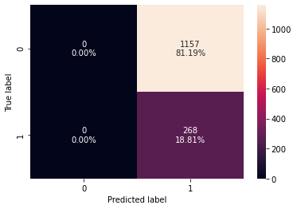

```python
#Calculating different metrics
lg_bagging_estimator_tuned_model_train_perf=model_performance_classification_sklearn(lg_bagging_estimator_tuned,X_train,y_train)
print("Training performance:\n", lg_bagging_estimator_tuned_model_train_perf)
lg_bagging_estimator_tuned_model_test_perf=model_performance_classification_sklearn(lg_bagging_estimator_tuned,X_test,y_test)
print("Testing performance:\n", lg_bagging_estimator_tuned_model_test_perf)

#Creating confusion matrix
confusion_matrix_sklearn(lg_bagging_estimator_tuned,X_test,y_test)
```

> **Observations:**
> - After hyperparameter tuning both training and test recall score is 1.
> - Assumption is that it is overfitting both training and test dataset, by reducing the Accuracy and Precision score to very low.
> - Since the accuracy and precision score is very low, this model cannot be useful.

## Bagging Classifier with DecisionTreeClassifier

```
Training performance:
    Accuracy    Recall  Precision        F1
0  0.990367  0.950479   0.998322  0.973813
Testing performance:
    Accuracy   Recall  Precision        F1
0   0.89193  0.55597   0.809783  0.659292
```

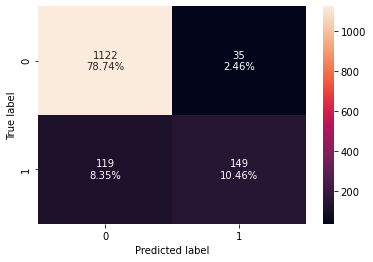

```python
#Fitting the model, Default base_estimator for BaggingClassifier is DecisionTreeClassifier
dt_bagging_classifier = BaggingClassifier(random_state=1)
dt_bagging_classifier.fit(X_train,y_train)

#Calculating different metrics
dt_bagging_classifier_model_train_perf=model_performance_classification_sklearn(dt_bagging_classifier,X_train,y_train)
print("Training performance:\n", dt_bagging_classifier_model_train_perf)
dt_bagging_classifier_model_test_perf=model_performance_classification_sklearn(dt_bagging_classifier,X_test,y_test)
print("Testing performance:\n", dt_bagging_classifier_model_test_perf)

#Creating confusion matrix
confusion_matrix_sklearn(dt_bagging_classifier,X_test,y_test)
```

> **Observations:**
> - Training and testing recall scores are 0.95 and 0.55 respectively.
> - The model is highly overfitted for recall score.
> - Although Accuracy and Precision looks good.

### Hyperparameter Tuning

```python
# Choose the type of classifier.
dt_bagging_estimator_tuned = BaggingClassifier(random_state=1)

# Grid of parameters to choose from
parameters = {'max_samples': [0.7,0.8,0.9,1],
              'max_features': [0.7,0.8,0.9,1],
              'n_estimators' : [20,40,80,100],
             }

# Type of scoring used to compare parameter combinations
scorer = metrics.make_scorer(metrics.recall_score)

# Run the grid search
grid_obj = GridSearchCV(dt_bagging_estimator_tuned, parameters, scoring=scorer, cv=5, n_jobs=-1)
grid_obj = grid_obj.fit(X_train, y_train)

# Set the clf to the best combination of parameters
dt_bagging_estimator_tuned = grid_obj.best_estimator_

# Fit the best algorithm to the data.
dt_bagging_estimator_tuned.fit(X_train, y_train)
```

```
BaggingClassifier(max_features=0.9, max_samples=0.9, n_estimators=100,
                  random_state=1)
```

```
Training performance:
    Accuracy  Recall  Precision   F1
0       1.0     1.0        1.0  1.0
Testing performance:
    Accuracy    Recall  Precision       F1
0  0.911579  0.600746   0.894444  0.71875
```

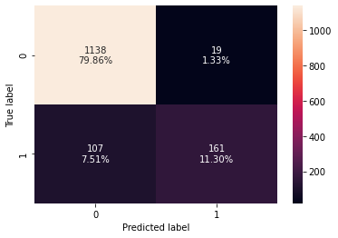

```python
#Calculating different metrics
dt_bagging_estimator_tuned_model_train_perf=model_performance_classification_sklearn(dt_bagging_estimator_tuned,X_train,y_train)
print("Training performance:\n", dt_bagging_estimator_tuned_model_train_perf)
dt_bagging_estimator_tuned_model_test_perf=model_performance_classification_sklearn(dt_bagging_estimator_tuned,X_test,y_test)
print("Testing performance:\n", dt_bagging_estimator_tuned_model_test_perf)

#Creating confusion matrix
confusion_matrix_sklearn(dt_bagging_estimator_tuned,X_test,y_test)
```

> **Observations:**
> - After hyperparameter tuning, Training and testing recall scores are 1.0 and 0.60 respectively.
> - We don't see much improvement after tuning. The model is highly overfitted for recall score.
> - Although Accuracy and Precision have improved.

BaggingClassifier does not have feature importance as output param.

## AdaBoost Classifier

```
Training performance:
    Accuracy    Recall  Precision       F1
0  0.847381  0.309904    0.72119  0.43352
Testing performance:
    Accuracy    Recall  Precision        F1
0  0.825263  0.268657      0.576  0.366412
```

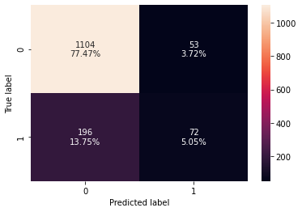

```python
#Fitting the model
ab_classifier = AdaBoostClassifier(random_state=1)
ab_classifier.fit(X_train,y_train)

#Calculating different metrics
ab_classifier_model_train_perf=model_performance_classification_sklearn(ab_classifier,X_train,y_train)
print("Training performance:\n", ab_classifier_model_train_perf)
ab_classifier_model_test_perf=model_performance_classification_sklearn(ab_classifier,X_test,y_test)
print("Testing performance:\n", ab_classifier_model_test_perf)

#Creating confusion matrix
confusion_matrix_sklearn(ab_classifier,X_test,y_test)
```

> **Observations:**
> - Training and testing recall scores are 0.30 and 0.26 respectively.
> - Although the model is not overfitted but recall score is unacceptable.
> - Accuracy and Precision looks good for training dataset but not for test dataset.

### Hyperparameter Tuning

```python
# Choose the type of classifier.
abc_tuned = AdaBoostClassifier(random_state=1)

# Grid of parameters to choose from
parameters = {
    #Let's try different max_depth for base_estimator
    "base_estimator":[DecisionTreeClassifier(max_depth=3),DecisionTreeClassifier(max_depth=5),
                      DecisionTreeClassifier(max_depth=7)],
    "n_estimators": [20,40,80,100],
    "learning_rate":np.arange(0.1,2,0.1)
}

# Type of scoring used to compare parameter  combinations
scorer = metrics.make_scorer(metrics.recall_score)

# Run the grid search
grid_obj = GridSearchCV(abc_tuned, parameters, scoring=scorer, cv=5, n_jobs=-1)
grid_obj = grid_obj.fit(X_train, y_train)

# Set the clf to the best combination of parameters
abc_tuned = grid_obj.best_estimator_

# Fit the best algorithm to the data.
abc_tuned.fit(X_train, y_train)
```

```
AdaBoostClassifier(base_estimator=DecisionTreeClassifier(max_depth=7),
                   learning_rate=0.1, n_estimators=20, random_state=1)
```

```
Training performance:
    Accuracy    Recall  Precision        F1
0  0.980734  0.897764        1.0  0.946128
Testing performance:
    Accuracy    Recall  Precision        F1
0  0.891228  0.548507   0.812155  0.654788
```

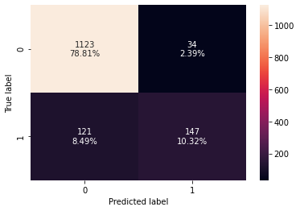

```python
#Calculating different metrics
abc_tuned_model_train_perf=model_performance_classification_sklearn(abc_tuned,X_train,y_train)
print("Training performance:\n", abc_tuned_model_train_perf)
abc_tuned_model_test_perf=model_performance_classification_sklearn(abc_tuned,X_test,y_test)
print("Testing performance:\n", abc_tuned_model_test_perf)

#Creating confusion matrix
confusion_matrix_sklearn(abc_tuned,X_test,y_test)
```

> **Observations:**
> - After hyperparameter tuning, Training and testing recall scores are 0.89 and 0.54 respectively.
> - There is improvement after tuning the model is highly overfitted for recall score.
> - Although Accuracy and Precision have improved.

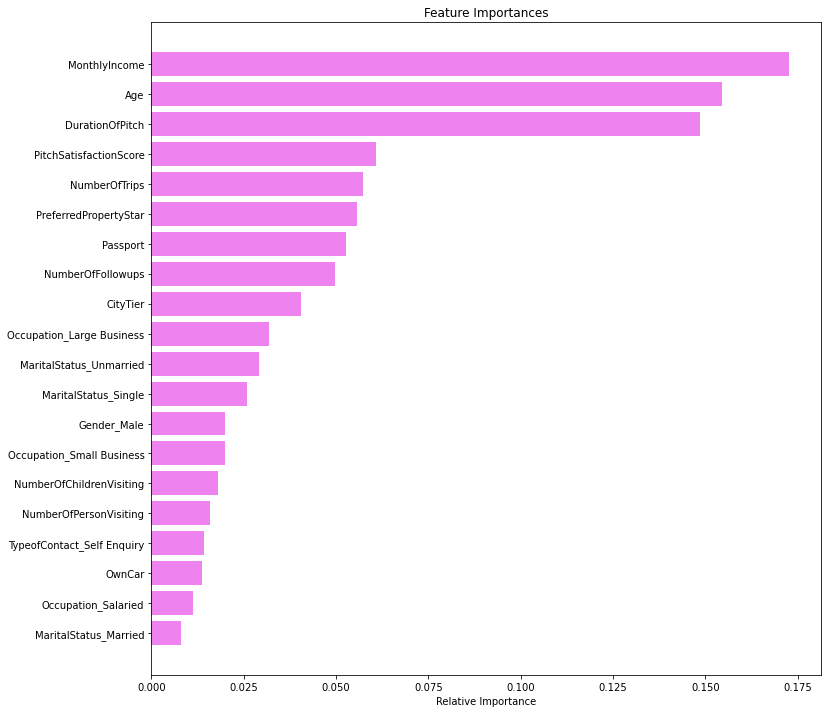

```python
show_feature_imp(abc_tuned)
```

> **Observations:**
> - The model has given high importance to MonthlyIncome, Age and DurationOfPitch.
> - It has also given importance to PitchSatisfactionScore, NumberOfTrips, PreferredPropertyStar, Passport
> - Very low importance to OwnCar, Salaried and Married customers.

## Gradient Boosting Classifier

```
Training performance:
    Accuracy    Recall  Precision        F1
0  0.882902  0.434505   0.885993  0.583065
Testing performance:
    Accuracy    Recall  Precision        F1
0  0.852632  0.343284   0.730159  0.467005
```

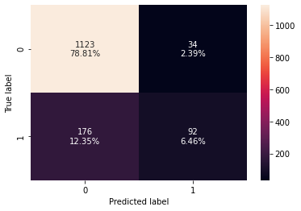

```python
#Fitting the model
gb_classifier = GradientBoostingClassifier(random_state=1)
gb_classifier.fit(X_train,y_train)

#Calculating different metrics
gb_classifier_model_train_perf=model_performance_classification_sklearn(gb_classifier,X_train,y_train)
print("Training performance:\n",gb_classifier_model_train_perf)
gb_classifier_model_test_perf=model_performance_classification_sklearn(gb_classifier,X_test,y_test)
print("Testing performance:\n",gb_classifier_model_test_perf)

#Creating confusion matrix
confusion_matrix_sklearn(gb_classifier,X_test,y_test)
```

> **Observations:**
> - Training and testing recall scores are 0.43 and 0.34 respectively.
> - Although the model is not overfitted but recall score is unacceptable.
> - Accuracy and Precision looks good for training dataset but not for test dataset.

### Hyperparameter Tuning

```python
# Choose the type of classifier.
gbc_tuned = GradientBoostingClassifier(init=AdaBoostClassifier(random_state=1),random_state=1)

# Grid of parameters to choose from
parameters = {
    "n_estimators": [100,150,200,250],
    "subsample":[0.8,0.9,1],
    "max_features":[0.7,0.8,0.9,1]
}

# Type of scoring used to compare parameter combinations
scorer = metrics.make_scorer(metrics.recall_score)

# Run the grid search
grid_obj = GridSearchCV(gbc_tuned, parameters, scoring=scorer, cv=5, n_jobs=-1)
grid_obj = grid_obj.fit(X_train, y_train)

# Set the clf to the best combination of parameters
gbc_tuned = grid_obj.best_estimator_

# Fit the best algorithm to the data.
gbc_tuned.fit(X_train, y_train)
```

```
GradientBoostingClassifier(init=AdaBoostClassifier(random_state=1),
                           max_features=0.8, n_estimators=250, random_state=1,
                           subsample=0.9)
```

```
Training performance:
    Accuracy    Recall  Precision        F1
0  0.918724  0.607029   0.940594  0.737864
Testing performance:
    Accuracy    Recall  Precision        F1
0  0.861754  0.429104    0.72327  0.538642
```

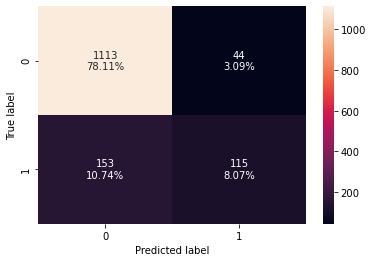

```python
#Calculating different metrics
gbc_tuned_model_train_perf=model_performance_classification_sklearn(gbc_tuned,X_train,y_train)
print("Training performance:\n",gbc_tuned_model_train_perf)
gbc_tuned_model_test_perf=model_performance_classification_sklearn(gbc_tuned,X_test,y_test)
print("Testing performance:\n",gbc_tuned_model_test_perf)

#Creating confusion matrix
confusion_matrix_sklearn(gbc_tuned,X_test,y_test)
```

> **Observations:**
> - After hyperparameter tuning, Training and testing recall scores are 0.60 and 0.42 respectively.
> - The scores have slightly improved but recall score is low.
> - The model is overfitted.

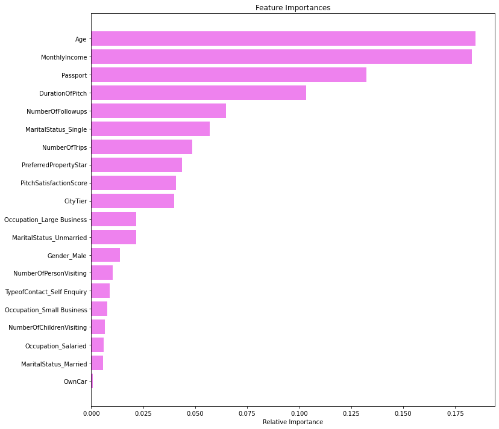

```python
show_feature_imp(gbc_tuned)
```

> **Observations:**
> - The model has given high importance to Age, MonthlyIncome, Passport and DurationOfPitch.
> - It has also given importance to NumberOfFollowups, Single, NumberOfTrips, PreferredPropertyStar, CityTier
> - Very low importance to OwnCar, Salaried and Married customers.

## XGBoost Classifier

```
Training performance:
    Accuracy    Recall  Precision        F1
0  0.999699  0.998403        1.0  0.999201
Testing performance:
    Accuracy    Recall  Precision        F1
0  0.901053  0.615672   0.812808  0.700637
```

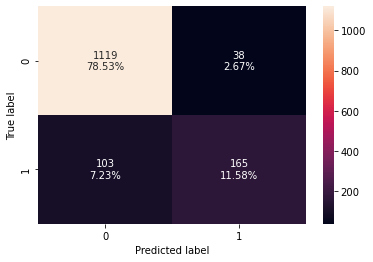

```python
#Fitting the model
xgb_classifier = XGBClassifier(random_state=1, eval_metric='logloss')
xgb_classifier.fit(X_train,y_train)

#Calculating different metrics
xgb_classifier_model_train_perf=model_performance_classification_sklearn(xgb_classifier,X_train,y_train)
print("Training performance:\n",xgb_classifier_model_train_perf)
xgb_classifier_model_test_perf=model_performance_classification_sklearn(xgb_classifier,X_test,y_test)
print("Testing performance:\n",xgb_classifier_model_test_perf)

#Creating confusion matrix
confusion_matrix_sklearn(xgb_classifier,X_test,y_test)
```

### Hyperparameter Tuning

```python
# Choose the type of classifier.
xgb_tuned = XGBClassifier(random_state=1, eval_metric='logloss')

# Grid of parameters to choose from
parameters = {
    "n_estimators": [10,30,50],
    "scale_pos_weight":[1,2,5],
    "subsample":[0.7,0.9,1],
    "learning_rate":[0.05, 0.1,0.2],
    "colsample_bytree":[0.7,0.9,1],
    "colsample_bylevel":[0.5,0.7,1]
}

# Type of scoring used to compare parameter combinations
scorer = metrics.make_scorer(metrics.recall_score)

# Run the grid search
grid_obj = GridSearchCV(xgb_tuned, parameters,scoring=scorer, cv=5, n_jobs=-1)
grid_obj = grid_obj.fit(X_train, y_train)

# Set the clf to the best combination of parameters
xgb_tuned = grid_obj.best_estimator_

# Fit the best algorithm to the data.
xgb_tuned.fit(X_train, y_train)
```

```
XGBClassifier(base_score=0.5, booster='gbtree', colsample_bylevel=0.5,
              colsample_bynode=1, colsample_bytree=0.7,
              enable_categorical=False, eval_metric='logloss', gamma=0,
              gpu_id=-1, importance_type=None, interaction_constraints='',
              learning_rate=0.05, max_delta_step=0, max_depth=6,
              min_child_weight=1, missing=nan, monotone_constraints='()',
              n_estimators=50, n_jobs=12, num_parallel_tree=1, predictor='auto',
              random_state=1, reg_alpha=0, reg_lambda=1, scale_pos_weight=5,
              subsample=1, tree_method='exact', validate_parameters=1,
              verbosity=None)
```

```
Training performance:
    Accuracy    Recall  Precision        F1
0  0.888922  0.873802   0.653524  0.747779
Testing performance:
    Accuracy    Recall  Precision        F1
0   0.81614  0.716418   0.507937  0.594427
```

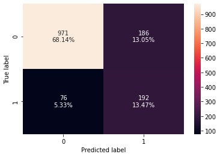

```python
#Calculating different metrics
xgb_tuned_model_train_perf=model_performance_classification_sklearn(xgb_tuned,X_train,y_train)
print("Training performance:\n",xgb_tuned_model_train_perf)
xgb_tuned_model_test_perf=model_performance_classification_sklearn(xgb_tuned,X_test,y_test)
print("Testing performance:\n",xgb_tuned_model_test_perf)

#Creating confusion matrix
confusion_matrix_sklearn(xgb_tuned,X_test,y_test)
```

> **Observations:**
> - Training and testing recall scores are 0.87 and 0.71 respectively.
> - The tuned XGBoost model has given a better recall score then all previous models on test data.
> - Accuracy and Precision looks good.

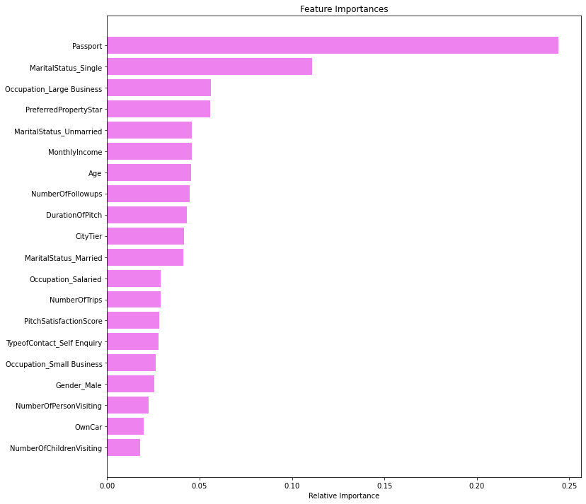

```python
show_feature_imp(xgb_tuned)
```

> **Observations:**
> - The model has given high importance to Passport and Single followed by occupation Large Business and PreferredPropertyStar.
> - It has also given importance to Unmarried, MonthlyIncome, Age, NumberOfFollowups, DurationOfPitch, CityTier
> - Interestingly given low importance to Male, OwnCar, NumberOfPersonVisiting and NumberOfChildrenVisiting.

## Stacking Classifier

```python
estimators = [('Ada Boost',AdaBoostClassifier(random_state=1)), ('Gradient Boost',GradientBoostingClassifier(random_state=1))]

final_estimator = XGBClassifier(random_state=1, eval_metric='logloss')

stacking_classifier= StackingClassifier(estimators=estimators,final_estimator=final_estimator)

stacking_classifier.fit(X_train,y_train)
```

```
StackingClassifier(estimators=[('Ada Boost',
                                AdaBoostClassifier(random_state=1)),
                               ('Gradient Boost',
                                GradientBoostingClassifier(random_state=1))],
                   final_estimator=XGBClassifier(base_score=None, booster=None,
                                                 colsample_bylevel=None,
                                                 colsample_bynode=None,
                                                 colsample_bytree=None,
                                                 enable_categorical=False,
                                                 eval_metric='logloss',
                                                 gamma=None, gpu_id=None,
                                                 importance_ty...
                                                 interaction_constraints=None,
                                                 learning_rate=None,
                                                 max_delta_step=None,
                                                 max_depth=None,
                                                 min_child_weight=None,
                                                 missing=nan,
                                                 monotone_constraints=None,
                                                 n_estimators=100, n_jobs=None,
                                                 num_parallel_tree=None,
                                                 predictor=None, random_state=1,
                                                 reg_alpha=None,
                                                 reg_lambda=None,
                                                 scale_pos_weight=None,
                                                 subsample=None,
                                                 tree_method=None,
                                                 validate_parameters=None,
                                                 verbosity=None))
```

```
Training performance:
    Accuracy    Recall  Precision        F1
0  0.869055  0.463259   0.745501  0.571429
Testing performance:
    Accuracy    Recall  Precision        F1
0      0.84  0.354478   0.633333  0.454545
```

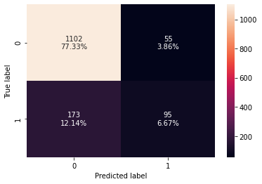

```python
#Calculating different metrics
stacking_classifier_model_train_perf=model_performance_classification_sklearn(stacking_classifier,X_train,y_train)
print("Training performance:\n",stacking_classifier_model_train_perf)
stacking_classifier_model_test_perf=model_performance_classification_sklearn(stacking_classifier,X_test,y_test)
print("Testing performance:\n",stacking_classifier_model_test_perf)

#Creating confusion matrix
confusion_matrix_sklearn(stacking_classifier,X_test,y_test)
```

> **Observations:**
> - Training and testing recall scores are 0.46 and 0.35 respectively.
> - Although the model is not overfitted but recall score is not very good.
> - Accuracy and Precision looks good for training dataset but not for test dataset.
> - More different types of models need to be tried to improve the recall score for StackingClassifier.

## Comparing all models

### Training Performance Comparison

```python
# training performance comparison
models_train_comp_df = pd.concat(
    [d_tree_model_train_perf.T,dtree_estimator_model_train_perf.T,rf_estimator_model_train_perf.T,rf_tuned_model_train_perf.T,
     dt_bagging_classifier_model_train_perf.T,dt_bagging_estimator_tuned_model_train_perf.T,ab_classifier_model_train_perf.T,
     abc_tuned_model_train_perf.T,gb_classifier_model_train_perf.T,gbc_tuned_model_train_perf.T,xgb_classifier_model_train_perf.T,
    xgb_tuned_model_train_perf.T,stacking_classifier_model_train_perf.T],
    axis=1,
)
models_train_comp_df.columns = [
    "Decision Tree",
    "Decision Tree Estimator",
    "Random Forest Estimator",
    "Random Forest Tuned",
    "Bagging Classifier (DT)",
    "Bagging Estimator Tuned (DT)",
    "Adaboost Classifier",
    "Adabosst Classifier Tuned",
    "Gradient Boost Classifier",
    "Gradient Boost Classifier Tuned",
    "XGBoost Classifier",
    "XGBoost Classifier Tuned",
    "Stacking Classifier"]
print("Training performance comparison:")
models_train_comp_df.T.sort_values(by='Recall', ascending=False)
```

```
Training performance comparison:
```

|  | Accuracy | Recall | Precision | F1 |
| --- | --- | --- | --- | --- |
| Decision Tree | 1.000000 | 1.000000 | 1.000000 | 1.000000 |
| Decision Tree Estimator | 1.000000 | 1.000000 | 1.000000 | 1.000000 |
| Random Forest Estimator | 1.000000 | 1.000000 | 1.000000 | 1.000000 |
| Bagging Estimator Tuned (DT) | 1.000000 | 1.000000 | 1.000000 | 1.000000 |
| XGBoost Classifier | 0.999699 | 0.998403 | 1.000000 | 0.999201 |
| Bagging Classifier (DT) | 0.990367 | 0.950479 | 0.998322 | 0.973813 |
| Adabosst Classifier Tuned | 0.980734 | 0.897764 | 1.000000 | 0.946128 |
| XGBoost Classifier Tuned | 0.888922 | 0.873802 | 0.653524 | 0.747779 |
| Random Forest Tuned | 0.745334 | 0.699681 | 0.399635 | 0.508711 |
| Gradient Boost Classifier Tuned | 0.918724 | 0.607029 | 0.940594 | 0.737864 |
| Stacking Classifier | 0.869055 | 0.463259 | 0.745501 | 0.571429 |
| Gradient Boost Classifier | 0.882902 | 0.434505 | 0.885993 | 0.583065 |
| Adaboost Classifier | 0.847381 | 0.309904 | 0.721190 | 0.433520 |

### Testing Performance Comparison

```python
# testing performance comparison
models_test_comp_df = pd.concat(
    [d_tree_model_test_perf.T,dtree_estimator_model_test_perf.T,rf_estimator_model_test_perf.T,rf_tuned_model_test_perf.T,
     dt_bagging_classifier_model_test_perf.T,dt_bagging_estimator_tuned_model_test_perf.T,ab_classifier_model_test_perf.T,
     abc_tuned_model_test_perf.T,gb_classifier_model_test_perf.T,gbc_tuned_model_test_perf.T,xgb_classifier_model_test_perf.T,
    xgb_tuned_model_test_perf.T,stacking_classifier_model_test_perf.T],
    axis=1,
)
models_test_comp_df.columns = [
    "Decision Tree",
    "Decision Tree Estimator",
    "Random Forest Estimator",
    "Random Forest Tuned",
    "Bagging Classifier (DT)",
    "Bagging Estimator Tuned (DT)",
    "Adaboost Classifier",
    "Adabosst Classifier Tuned",
    "Gradient Boost Classifier",
    "Gradient Boost Classifier Tuned",
    "XGBoost Classifier",
    "XGBoost Classifier Tuned",
    "Stacking Classifier"]
print("Testing performance comparison:")
models_test_comp_df.T.sort_values(by='Recall', ascending=False)
```

```
Testing performance comparison:
```

|  | Accuracy | Recall | Precision | F1 |
| --- | --- | --- | --- | --- |
| XGBoost Classifier Tuned | 0.816140 | 0.716418 | 0.507937 | 0.594427 |
| Random Forest Tuned | 0.722807 | 0.671642 | 0.369610 | 0.476821 |
| Decision Tree | 0.853333 | 0.652985 | 0.601375 | 0.626118 |
| Decision Tree Estimator | 0.853333 | 0.652985 | 0.601375 | 0.626118 |
| XGBoost Classifier | 0.901053 | 0.615672 | 0.812808 | 0.700637 |
| Bagging Estimator Tuned (DT) | 0.911579 | 0.600746 | 0.894444 | 0.718750 |
| Bagging Classifier (DT) | 0.891930 | 0.555970 | 0.809783 | 0.659292 |
| Adabosst Classifier Tuned | 0.891228 | 0.548507 | 0.812155 | 0.654788 |
| Random Forest Estimator | 0.897544 | 0.503731 | 0.912162 | 0.649038 |
| Gradient Boost Classifier Tuned | 0.861754 | 0.429104 | 0.723270 | 0.538642 |
| Stacking Classifier | 0.840000 | 0.354478 | 0.633333 | 0.454545 |
| Gradient Boost Classifier | 0.852632 | 0.343284 | 0.730159 | 0.467005 |
| Adaboost Classifier | 0.825263 | 0.268657 | 0.576000 | 0.366412 |

## Conclusion

We analyzed the historical data of "Visit With Us" company's previous travel package campaigns and their conversion rate including customer interaction parameters using different EDA techniques. We also explored different Ensemble Techniques, such as Bagging, Boosting and Stacking algorithms to build various predictive models to better understand the features that may have influenced the campaign result.

Based on results of EDA and model predictions below conclusions can be draw:

- Mostly younger customers between 25 and 40 years of age have taken one of previous the travel packages. And many models such as Random Forest, AdaBoost, GradientBoost have given high importance to Age.
- People who have passports seemed to have taken travel packages and models also have given high importance to this feature. Specially XGBoost has given highest importance to Passport.
- Customers who are single and unmarried have taken previous travel package more than other statuses and models also predicts the same.
- Out of five different occupations (Executive, Manager, Sr. Manager, AVP, VP), relatively lower monthly income occupations such as Executive, Manager and Sr. Manager have preferred to buy a travel package from the company. Since monthly income and designations are correlated. Many models also given high importance to monthly income feature.
- Customers location also seems to have an influence in the conversion rate. Customers from Tier 3 cities have taken travel packages more than others.
- Occupations in Large Businesses and Salaried seemed to have influence in the deciding if a customer would by a travel package.
- Need less to mention that Self Enquired customers definitely have higher chance of taking a travel package.
- Many models are also suggesting customers who preferred good hotels/resorts with avobe average property ratings are more likely to buy travel packages.
- Other customer features such as Owning a car or number of people or children planning to visit or even gender, number of trips etc. have less importance or significance in decision making for a customer to buy a travel package.

On the customer interaction analysis we have some important conclusions as below:

- Duration of pitch plays a big role in the conversion rate of potential customer to buy a travel package. Most of the models have given high importance to this feature.
- PitchSatisfactionScore is also important factor for many customer in making a decision.
- Number of followups in many cases helped deciding a customer to buy previous travel packages.

## Recommendations

The company "Visit With Us" is now planning to launch a new product i.e. Wellness Tourism Package. Based on the previous tavel packages campaign data, analysis and model predictions following recommendations can be provided to policy makers and marketing team to optimize the cost of campaign and increase the customer base.

Customers can be profiled to below groups in order of priority as campaigning targets:

- Younger aged customers who are single or unmarried and having passports: This group of customers should be the go to customers for the new travel package campaign.
- Customers working as Executive, Managers and Sr. Manager in Large Businesses and Salaried occupation are will be the next targets.
- Customers residing in Tier 3 and Tier 2 cities and earlier preferred good property ratings, had few number of trips are next.

When customer self enquires, sales representatives handling the case should take these customrs seriously with proper product pitch and followups as they have high probability in buying the package.

It is recommended that sales representatives are properly trained to give the detailed product pitch on the Wellness Tourism Package, increase their satisfaction score and follow up multiple times as these customer interaction behaviors have high importance towards increasing the customer base.

In order to increase the customer base further in future company needs to investigate why earlier travel packages were not popular with aged and wealthy customers with higher designation such as AVP and VP. Also it needs to be investigated how to attract customers from Tier 1 and Tier 2 cities more to increase the customer base in those cities.